# Liked TikTok statistics

## Overview

There is the data breakdown of about 22 TikToks I liked over the course of the collection period for Project 4. Some of the data I collected was content type, date posted, and interactions. I gathered this data on my own with a Google Form when ever I found myself liking a TikTok.

## Plot 1 - What type of content do I like?

[figure not shown]

The most common type of content I liked on the 12th of May was “Funny” with 9 TikToks. When looking at the median likes by each type, “Funny” also had the highest most likes out of the content types I came across. “Relatable” also had more likes than “Animal” even though it had far fewer TikToks during my session. “Discussion” only had one TikTok and was far below the median line which suggests I only occasionally come across niche content when it comes to discussions.

## Plot 2 - Do more views mean more likes?

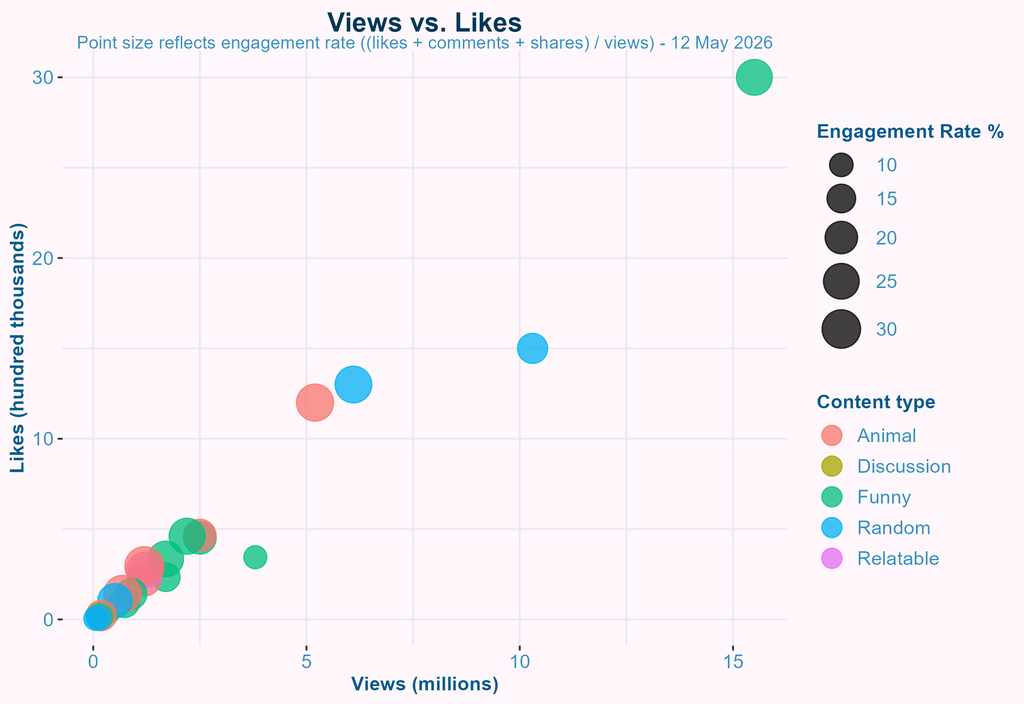

## Plot 3 - Does a video’s age affect how many views it gets?

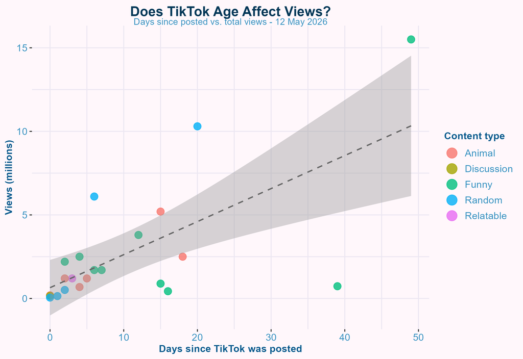

There is a positive trend that shows older videos have more views. This makes sense since they have had more opportunity to be discovered and seen. However the spread of the data is wide presented by the shaded region. This means there is some uncertainty in the trend. For instance, a “Random” TikTok had an age of 20 days and had more than 10 million views whereas a “Funny” TikTok had an age of almost 40 days and had less than a million views.

## Conclusion

To summarise, from the recent data I captured for Project 4, it showed my most liked content falls under the “Funny” or “Animal” category. While there were the odd discussion posts, most of the videos I liked just made me laugh. Engagement seems to be consistent across most categories and most of the videos I liked were below 3 million views but there will be the occasioanl standout TikTok. Most of the TikToks I saw were less than a week old but the algorithm still shows many videos that are older with many views.